# (Loan Data From Prosper)

#### MonthlyLoanPayment......(Numeric variable)

```python
df['MonthlyLoanPayment'].describe()
```

```
count    113937.000000
mean        272.475783
std         192.697812
min           0.000000
25%         131.620000
50%         217.740000
75%         371.580000
max        2251.510000
Name: MonthlyLoanPayment, dtype: float64
```

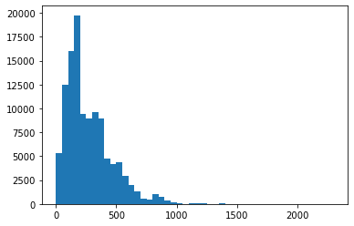

```python
bins = np.arange(0, 2251 + 50, 50)
plt.hist(data=df, x='MonthlyLoanPayment', bins=bins);
```

The plot is right skewed, let me scale it and use different bins sizes to have a better look.

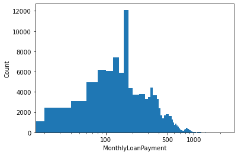

```python
bins = np.arange(0, 2251 + 20, 20)
plt.hist(data=df, x='MonthlyLoanPayment', bins=bins);
plt.xscale('log');
x_ticks = [100,500,1000]
plt.xticks(x_ticks,x_ticks);
plt.xlabel('MonthlyLoanPayment');
plt.ylabel('Count');
```

It shows now that monthly payments revolve around a big spike at nearly 200 and are mostly up to 1000.

*As I'm interested to see what features contribute to Loan payment completion on time, I'll seperate the dataset into two sub datasets, one for completed loans, to investigate more, what helped in completion if any, and another dataset that has all other LoanStatus categories but not 'completed'.*

```python
# Separate the dataset into two subsets based on LoanStatus category
df_completed = df[df['LoanStatus'] == 'Completed']
df_not_completed = df[df['LoanStatus'] != 'Completed']
```

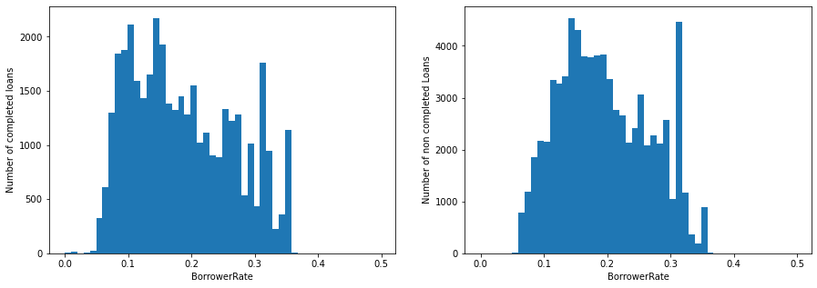

```python
# Compare BorrowerRate variable on both datasets, df_completed and df_not_completed
plt.subplots(figsize=(15,5))
plt.subplot(1,2,1)
sb.distplot(df_completed['BorrowerRate'], kde=False, hist_kws={'alpha':1});
plt.ylabel('Number of completed loans');
plt.subplot(1,2,2)
sb.distplot(df_not_completed['BorrowerRate'], kde=False, hist_kws={'alpha':1});
plt.ylabel('Number of non completed Loans');
```

Not completed loans are almost double the count of completed one in the same interest rate interval.

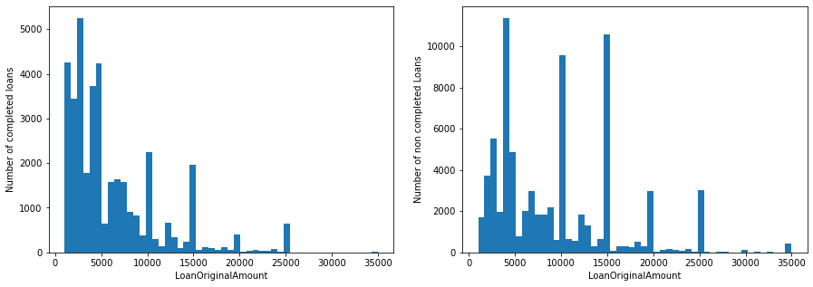

```python
# Compare LoanOriginalAmount variable on both datasets, df_completed and df_not_completed
plt.subplots(figsize=(15,5))
plt.subplot(1,2,1)
sb.distplot(df_completed['LoanOriginalAmount'], kde=False, hist_kws={'alpha':1});
plt.ylabel('Number of completed loans');
plt.subplot(1,2,2)
sb.distplot(df_not_completed['LoanOriginalAmount'], kde=False, hist_kws={'alpha':1});
plt.ylabel('Number of non completed Loans');
```

Now I can see some struggle in loan amounts over 15k, the completed loans up to 25k, one outlier on 35k. Same for not completed , it has spikes on the same points we stated earlier 5k, 10k, 15k , and some few counts on 20k and 25k. The plots are right skewed as stated before. which is logic as high loans are not easily pulled.

```python
df_completed['MonthlyLoanPayment'].describe()
```

```
count    38074.000000
mean       218.780775
std        182.227908
min          0.000000
25%         94.150000
50%        171.100000
75%        297.000000
max       2251.510000
Name: MonthlyLoanPayment, dtype: float64
```

```python
df_not_completed['MonthlyLoanPayment'].describe()
```

```
count    75863.000000
mean       299.424147
std        192.171191
min          0.000000
25%        156.410000
50%        258.030000
75%        395.960000
max       2163.630000
Name: MonthlyLoanPayment, dtype: float64
```

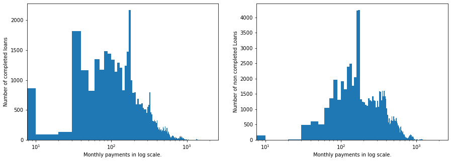

```python
# Compare MonthlyLoanPayment variable on both datasets, df_completed and df_not_completed
bins = np.arange(0, 2000+10, 10 )
plt.subplots(figsize=(15,5))
plt.subplot(1,2,1)
#sb.distplot(df_completed['MonthlyLoanPayment'], kde=False, hist_kws={'alpha':1});
plt.hist(data=df_completed, x='MonthlyLoanPayment', bins=bins);
plt.xscale('log')
plt.xlabel('Monthly payments in log scale.');
plt.ylabel('Number of completed loans');
plt.subplot(1,2,2)
#sb.distplot(df_not_completed['MonthlyLoanPayment'], kde=False, hist_kws={'alpha':1});
plt.hist(data=df_not_completed, x='MonthlyLoanPayment', bins=bins);
plt.xscale('log')
plt.xlabel('Monthly payments in log scale.');
plt.ylabel('Number of non completed Loans');
```

```python
df['StatedMonthlyIncome'].describe()
```

```
count    1.139370e+05
mean     5.608026e+03
std      7.478497e+03
min      0.000000e+00
25%      3.200333e+03
50%      4.666667e+03
75%      6.825000e+03
max      1.750003e+06
Name: StatedMonthlyIncome, dtype: float64
```

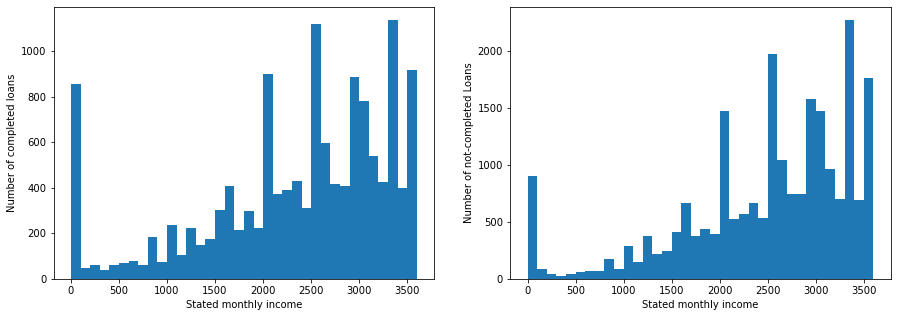

```python
# Compare StatedMonthlyIncome variable on both datasets, df_completed and df_not_completed
bins = np.arange(0, df['StatedMonthlyIncome'].value_counts().max()+100 , 100 )
plt.subplots(figsize=(15,5))
plt.subplot(1,2,1)
plt.hist(data=df_completed, x='StatedMonthlyIncome', bins=bins);
plt.xlabel('Stated monthly income');
plt.ylabel('Number of completed loans');
plt.subplot(1,2,2)
plt.hist(data=df_not_completed, x='StatedMonthlyIncome', bins=bins);
plt.xlabel('Stated monthly income');
plt.ylabel('Number of not-completed Loans');
```

I don't see much from that variable, whether it affects loan completion or not, but it might affect if combined with another variable in bivariate exploration or feature engineering later.

#### IncomeRange.....(Categorical Variable)

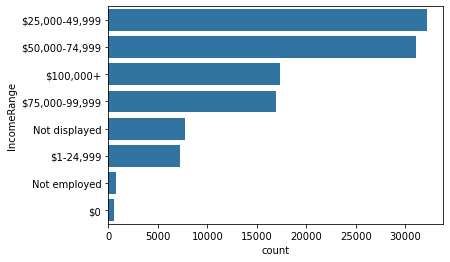

```python
# Order different categories
income_idx = df['IncomeRange'].value_counts().index
sb.countplot(data=df, y='IncomeRange', color=base_color, order=income_idx);
```

I see it a promising variable to get some insights on how income different ranges differ in loan status.

Next, Interested to see what Term (number of months) affect completion of loans

```python
# Number of months associated to pay loans
df['Term'].unique()
```

```
array([36, 60, 12], dtype=int64)
```

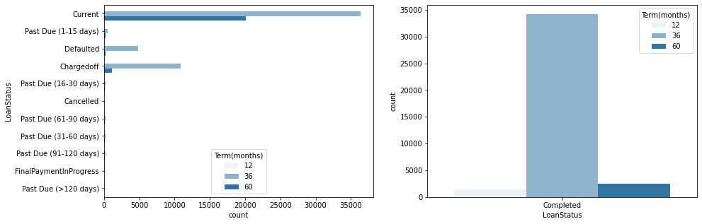

```python
# Compare Term variable on both datasets, df_completed and df_not_completed
plt.subplots(figsize=(15,5))
plt.subplot(1,2,1)
# Plot Term counts for not completed loans
sb.countplot(data=df_not_completed, y='LoanStatus', hue='Term', color=base_color);
plt.legend(title='Term(months)',loc=8);
plt.subplot(1,2,2)
# Plot Term counts for completed loans
sb.countplot(data=df_completed, x='LoanStatus', hue='Term', color=base_color);
plt.legend(title='Term(months)');
```

I see most not completed loans lie in 4 LoanStatus categories : 'Current','Chargedoff','Defaulted','Past Due (1-15 days)', get a closer look on these 4 categories.

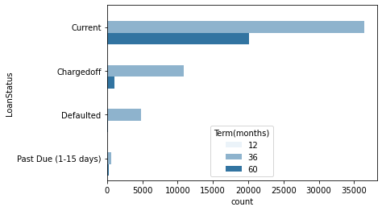

```python
# a closer look on the 4 major categories in df_not_completed concerning Term variable
df_status_sub = df_not_completed.loc[df_not_completed['LoanStatus'].isin(['Current','Chargedoff','Defaulted','Past Due (1-15 days)'])]
order_idx2 = df_status_sub['LoanStatus'].value_counts().index
sb.countplot(data=df_status_sub, y='LoanStatus', hue='Term', color=base_color, order=order_idx2);
plt.legend(title='Term(months)',loc=8);
```

As an initial conclusion concerning number of loan payment months, 36 months is the major value for completed and not completed loans.

#### ListingCategory

```python
# First I replaced numbers of numeric categories to see better differen loan borrower's reasons
df.replace({'ListingCategory (numeric)':{0:'Not Available', 1:'Debt Consolidation', 2:'Home Improvement', 3:'Business', 4:'Personal Loan', 5:'Student Use',
            6:'Auto', 7:'Other', 8:'Baby&Adoption', 9:'Boat', 10:'Cosmetic Procedure', 11:'Engagement Ring',
            12:'Green Loans', 13:'Household Expenses', 14:'Large Purchases', 15:'Medical/Dental', 16:'Motorcycle', 17:'RV', 18:'Taxes',
            19:'Vacation', 20:'Wedding Loans'}}, inplace=True)

df['ListingCategory (numeric)'].value_counts().nlargest(10)
```

```
Debt Consolidation    58308
Not Available         16965
Other                 10494
Home Improvement       7433
Business               7189
Auto                   2572
Personal Loan          2395
Household Expenses     1996
Medical/Dental         1522
Taxes                   885
Name: ListingCategory (numeric), dtype: int64
```

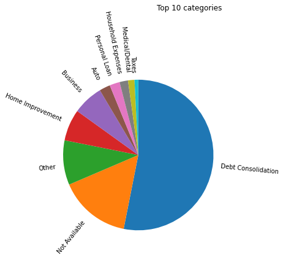

```python
plt.figure(figsize=[10,5])
ax = plt.pie(df['ListingCategory (numeric)'].value_counts().nlargest(10), labels=df['ListingCategory (numeric)'].value_counts().nlargest(10).index, counterclock=False, startangle=90, rotatelabels=True);
plt.axis('square');

plt.title('Top 10 categories',loc='right', pad=100);
```

Debt Consolidation is a favourite reason to take a loan.

### Univariate Exploration Conclusion

> I had to divide the dataset based on LoanStatus, whether completed or anything else, to see different features and their relation with completion of a loan.

## Bivariate Exploration

> I'll start by a pair plt diagram to get idea on several features relationships.

```python
# I need to scale the stated monthly income
df['MonthlyIncome'] = df['StatedMonthlyIncome']/1000
```

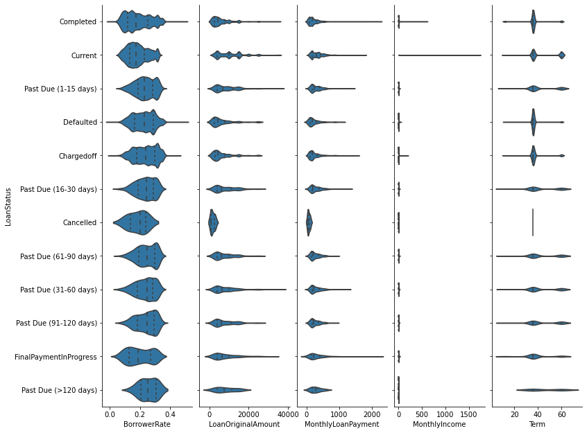

```python
plt.figure(figsize=[10,5])
g = sb.PairGrid(data=df, x_vars=['BorrowerRate','LoanOriginalAmount','MonthlyLoanPayment','MonthlyIncome','Term'],
               y_vars=['LoanStatus'], aspect=1.3, despine=True);
g.map(sb.violinplot, inner='quartile');
g.fig.set_size_inches(10,10)
```

- BorrowerRate has multimodal distribution with LoanStatus in most categories.
- LoanOriginalAmount has average low amount but right-skewed
- Same for MonthlyLoanPayment
- StatedMonthlyIncome seems it has outliers due to high range of values, I had to scale it but still skewed.
- Most loans seem to concentrate on the same term value.

#### Compare LoanStatus with BorrowerRate

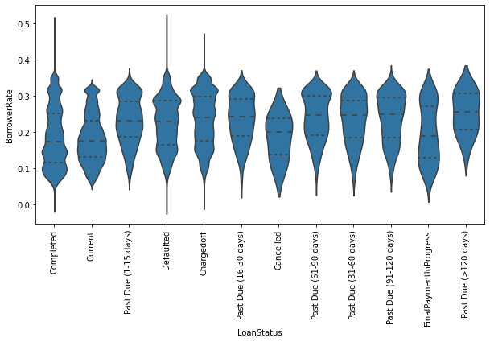

```python
# Get full insight on all loan status categories in the dataset and see the realtionship between them and Borrower rate
plt.figure(figsize=[10,5])
sb.violinplot(data=df, x='LoanStatus', y='BorrowerRate',inner='quartile', color=base_color);
plt.xticks(rotation=90);
```

I can see completed , final payments in progress and current loans have mean interest rate less than all others. It seems the low inyerest rate is a factor in that. Let's take a step further and analyse the late and problematic loans status.

```python
# Seperate the data to 2 subsets, based on LoanStatus
df_late = df.loc[df['LoanStatus'].isin(['Past Due (1-15 days)', 'Past Due (16-30 days)',
       'Past Due (61-90 days)', 'Past Due (31-60 days)',
       'Past Due (91-120 days)', 'Past Due (>120 days)'])]
df_problematic = df.loc[df['LoanStatus'].isin(['Defaulted','Chargedoff'])]
```

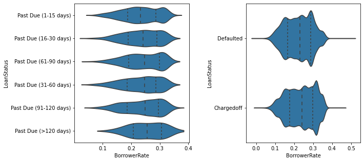

```python
# Compare loan status that have a problem and late in payments
plt.figure(figsize=[10,5])
plt.subplots_adjust(wspace=0.5)
plt.subplot(1,2,1)
sb.violinplot(data=df_late, y='LoanStatus', x='BorrowerRate',inner='quartile', color=base_color);
plt.subplot(1,2,2)
sb.violinplot(data=df_problematic, y='LoanStatus', x='BorrowerRate',inner='quartile', color=base_color);
```

The 6 categories that have late payments are 'Past Due (1-15 days)', 'Past Due (16-30 days)', 'Past Due (61-90 days)', 'Past Due (31-60 days)', 'Past Due (91-120 days)', 'Past Due (>120 days)' have a mean interest rate of 0.25

The 2 categories that have real problems are 'Defaulted' and 'Chargedoff' are right skewed with higher interest rates.

#### Compare LoanStatus and LoanOriginalAmount

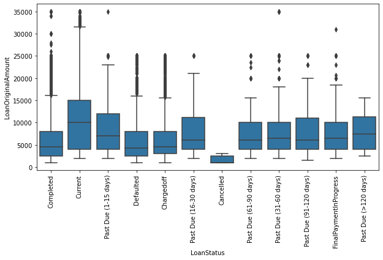

```python
# Get full insight on all loan status categories in the dataset and see the realtionship between them and Borrower rate
plt.figure(figsize=[10,5])
sb.boxplot(data=df, x='LoanStatus', y='LoanOriginalAmount', color=base_color);
plt.xticks(rotation=90);
```

The overlook says all categoreis except, cancelled and over 120 days late payments, are right skewed towards high loan amounts and have outliers on those amounts also. Compare between late , problematic and completed loans.

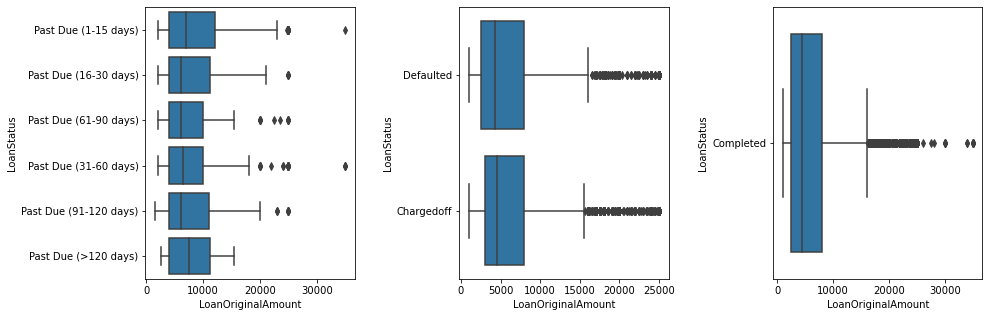

```python
plt.figure(figsize=[15,5])
plt.subplots_adjust(wspace=0.5)
plt.subplot(1,3,1)
sb.boxplot(data=df_late, y='LoanStatus', x='LoanOriginalAmount', color=base_color);
plt.subplot(1,3,2)
sb.boxplot(data=df_problematic, y='LoanStatus', x='LoanOriginalAmount', color=base_color);
plt.subplot(1,3,3)
sb.boxplot(data=df_completed, y='LoanStatus', x='LoanOriginalAmount', color=base_color);
```

The defaulted and chargedoff loans have similar box plots , it seems that loans that are defaulted gets chargedoff in a loan giver policy. The completed loans are mostly in the range of up to 10k, with some skewness and outliers on high loan amounts. What interests me that comparing all late, problematic and completed, I don't see that the loan amount affects much if the loan is completed or not.

#### Compare LoanStatus with MonthlyLoanPayment

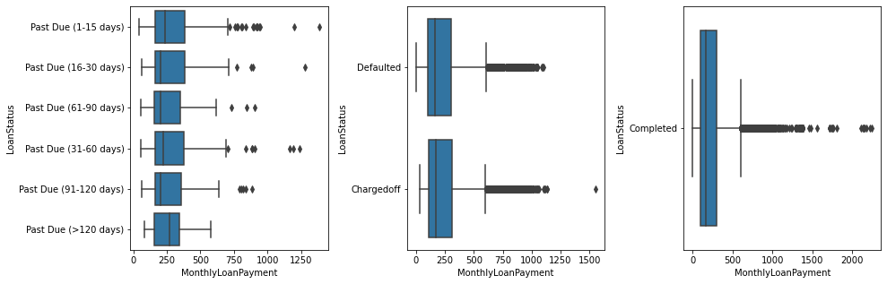

```python
plt.figure(figsize=[15,5])
plt.subplots_adjust(wspace=0.4)
plt.subplot(1,3,1)
sb.boxplot(data=df_late, x='MonthlyLoanPayment', y='LoanStatus', color=base_color);
plt.subplot(1,3,2)
sb.boxplot(data=df_problematic,x='MonthlyLoanPayment', y='LoanStatus', color=base_color);
plt.subplot(1,3,3)
sb.boxplot(data=df_completed, x='MonthlyLoanPayment', y='LoanStatus', color=base_color);
```

I notice that on completed loans, there are lots of outliers on high monthly payments, although all categories have mean monthly payments around 250.

#### Compare MonthlyLoanPayment and StatedMonthlyIncome

```python
df[['MonthlyLoanPayment','StatedMonthlyIncome']].describe()
```

|  | MonthlyLoanPayment | StatedMonthlyIncome |
| --- | --- | --- |
| count | 113937.000000 | 1.139370e+05 |
| mean | 272.475783 | 5.608026e+03 |
| std | 192.697812 | 7.478497e+03 |
| min | 0.000000 | 0.000000e+00 |
| 25% | 131.620000 | 3.200333e+03 |
| 50% | 217.740000 | 4.666667e+03 |
| 75% | 371.580000 | 6.825000e+03 |
| max | 2251.510000 | 1.750003e+06 |

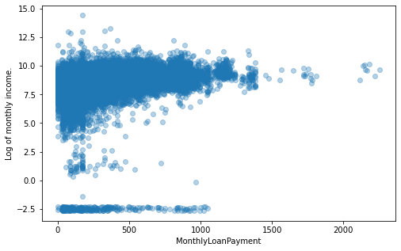

```python
bins_x = np.arange(0, 2300+100,100)
bins_y = np.arange(0, df['StatedMonthlyIncome'].value_counts().max()+1000, 1000)
plt.figure(figsize=[8,5])
sb.regplot(data=df, x='MonthlyLoanPayment', y=np.log(df['StatedMonthlyIncome']), fit_reg=False, x_jitter=0.2, y_jitter=0.2,
           scatter_kws={'alpha':1/3});
plt.ylabel('Log of monthly income.');
```

I had to scale the monthly income so that I get a deeper look on relationship between MonthlyLoanPayment and StatedMonthlyIncome , a slight positive but not strong one.

### Bivariate Conclusions

> As my point of interest is completion of a loan, I tried to see relationships between loan status and different features I saw relevant as Loan amount, interest rate, individuals income and monthly payments.

> Comparing Loanstatus categories against BorrowerRate , I saw completed and current loans have lower average interest rate than all other status categories. Also defaulted and chargedoff loans have skewness towards higher interest rates. so far I see BorrowerRate is an independant feature for loan status.

> Comparing Loanstatus categories against LoanOriginalAmount, surprisingly I didn't see a good relationship between the loan amount and completion or not status, however, defaulted and chargedoff categories seem to have same relationships with loan amount.

> Comparing Loanstatus categories against MonthlyLoanPayment, I notice lots of outliers on high monthly payments given loans are completed, although all categories have mean monthly payments around 250.

> Comparing MonthlyLoanPayment and StatedMonthlyIncome, not much to state other than a slight positive relationship between them.

> While working with the features I found relevant, I saw that combining StatedMonthly Income with MonthlyLoanPayment would be a good point to explore.

## Multivariate Exploration

#### Plot LoanStatus against BorrowerRate and LoanOriginalAmount

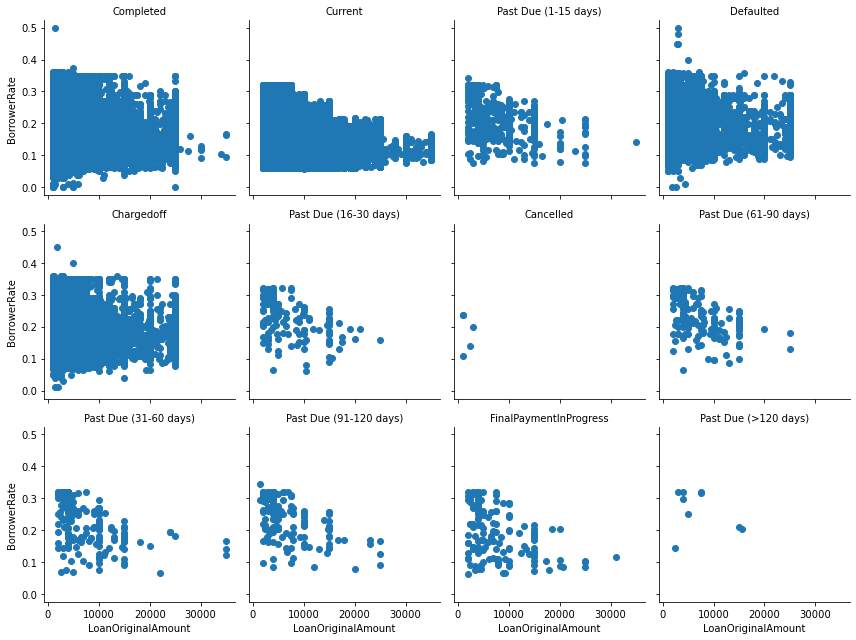

```python
# I want to focus here on 36 months term payments as I could see a relationship between this variable and completion rate.
df_term = df[df['Term']==36]
plt.figure(figsize=[15,8]);
g = sb.FacetGrid(data=df_term, col='LoanStatus', margin_titles=True, height=3, col_wrap=4);
g.map(plt.scatter, 'LoanOriginalAmount','BorrowerRate');
g.set_titles('{col_name}', fontdict={'fontsize':30});
```

This facet grid gives same relationships between interest rate and loan amount affecting loan status as we got by splitting the whole dataset on different subsets based on loan status, as stated before, I can't see a relationship between loan amount and loan status. Let's look on relationship between StatedMonthlyIncome, BorrowerRate and loan status.

#### Plot LoanStatus against BorrowerRate and StatedMonthlyIncome

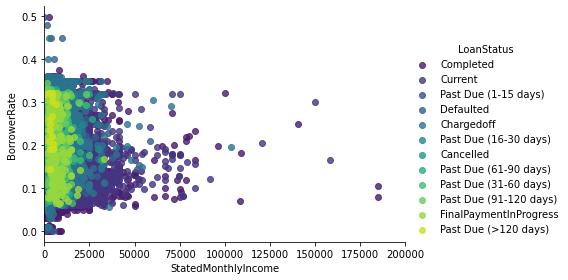

```python
g = sb.FacetGrid(data=df, hue='LoanStatus', palette='viridis', aspect=1.5, height=4);
g.map(sb.regplot, 'StatedMonthlyIncome', 'BorrowerRate', fit_reg=False);
plt.xlim([0,200000])
g.add_legend();
```

This graph implies that low monthly incomes < 25000 struggle to complete the loan payment, most past due payments lie in that range, also up to 0.4 Borrower rate gave nearly all completed loans. The completion rate is higher as higher the StatedMonthlyIncome is, given an interest rate not more than 0.35.

#### Plot LoanStatus against BorrowerRate and MonthlyLoanPayment

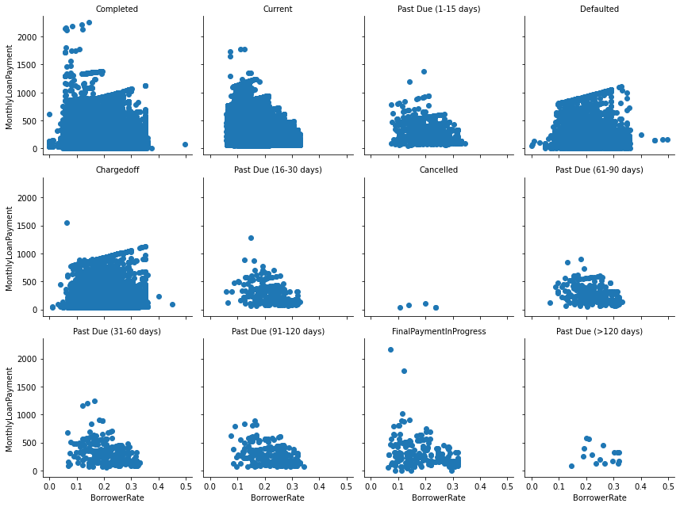

```python
plt.figure(figsize=[15,8]);
g = sb.FacetGrid(data=df, col='LoanStatus', margin_titles=True, height=3, col_wrap=4);
g.map(plt.scatter, 'BorrowerRate','MonthlyLoanPayment');
g.set_titles('{col_name}');
```

This plot gave good relationship between MonthlyLoanPayment and BorrowerRate and their relationship on loan status.

#### Feature Engineering

> As a further exploration, I'll add a new variable by multiplying the monthly payments times number of months to get the generated loan amount after interests and fees, and see if it has a relationship with loan status.

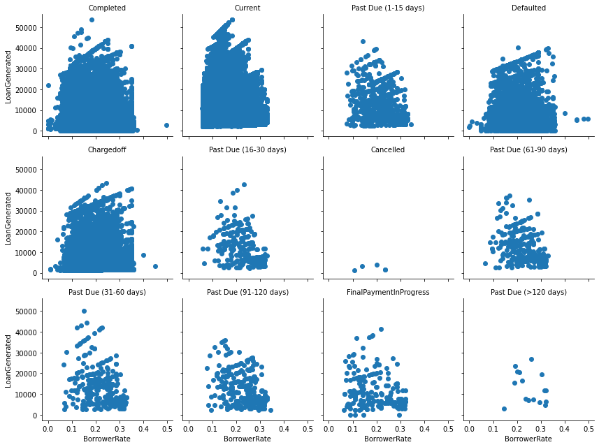

```python
df['LoanGenerated'] = df['Term'] * df['MonthlyLoanPayment']
plt.figure(figsize=[15,8]);
g = sb.FacetGrid(data=df, col='LoanStatus', margin_titles=True, height=3, col_wrap=4);
g.map(plt.scatter, 'BorrowerRate','LoanGenerated');
g.set_titles('{col_name}');
```

So far the relationship is strong between loan completion and interest rate and monthly payments.